# 1. Human length biased

### Generate lists of human genes biased by the length of the genes.

Use a gene info file derived from a gtf file from Ensembl containing all the genes and transcripts in the human genome. We then filter this for all the genes that are annotated with at least one functional category. We can extract the lengths of the genes from this filtered set of genes and plot them so that some thresholds for length categories can be determined.

| gene_name | length | log2_length |
| --- | --- | --- |
| OR4F5 | 6166 | 12.59 |
| OR4F29 | 994 | 9.96 |
| OR4F16 | 994 | 9.96 |
| NOC2L | 15106 | 13.88 |
| KLHL17 | 5135 | 12.33 |
| PLEKHN1 | 9383 | 13.2 |
| PERM1 | 6889 | 12.75 |
| HES4 | 1210 | 10.24 |
| ISG15 | 13402 | 13.71 |
| AGRN | 35998 | 15.14 |

[output cut: 17255 more lines]

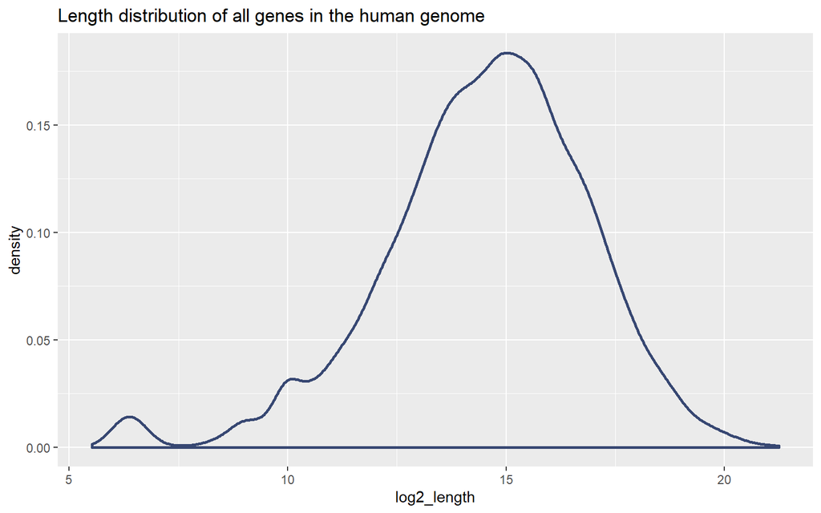

## Length thresholds

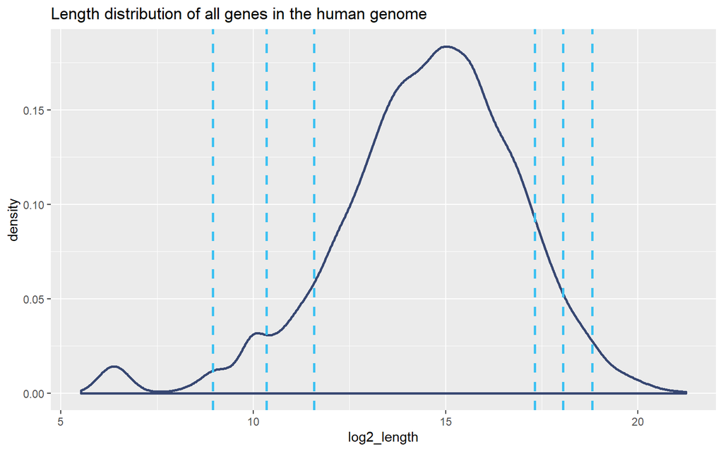

| name | value |
| --- | --- |
| 2% | 8.95 |
| 5% | 10.34 |
| 10% | 11.58 |
| 90% | 17.32 |
| 95% | 18.05 |
| 98% | 18.81 |

## Number of genes in each category

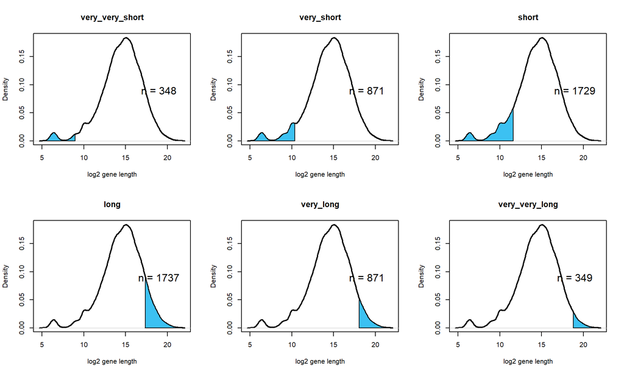

## Generating the biased gene sets and running the GO analysis

1. Randomly select 200 genes from the subset of genes in the long and short categories.  
2. Run functional enrichment analysis, record results.  
3. Repeat steps 1 and 2, 100 times.  
Repeat this for each length category.

| bias_category | n |
| --- | --- |
| long | 99 |
| short | 100 |
| very_long | 100 |
| very_short | 100 |
| very_very_long | 100 |
| very_very_short | 100 |

The table shows the number of functional enrichment analyses that returned 1 or more significantly enriched categories from the 100 that were run.

## Identified categories

The number of times that a functional category was identified from the 100 times that the analysis was run for each bias category. The table contains every functional category that appeared once or more in any of the bias categories.

| GO_category | very_very_short | very_short | short | long | very_long | very_very_long |
| --- | --- | --- | --- | --- | --- | --- |
| SUPERPATHWAY OF INOSITOL PHOSPHATE COMPOUNDS%HUMANCYC%PWY-6371 | 0 | 0 | 0 | 4 | 4 | 0 |
| D-&lt;I&gt;MYO&lt; I&gt;-INOSITOL-5-PHOSPHATE METABOLISM%HUMANCYC%PWY-6367 | 0 | 0 | 0 | 1 | 4 | 0 |
| PHOSPHOLIPASES%HUMANCYC%LIPASYN-PWY | 0 | 0 | 0 | 2 | 4 | 0 |
| D-&lt;I&gt;MYO&lt; I&gt;-INOSITOL (1,4,5)-TRISPHOSPHATE BIOSYNTHESIS%HUMANCYC%PWY-6351 | 0 | 0 | 0 | 1 | 8 | 0 |
| GLUCONEOGENESIS I%HUMANCYC%GLUCONEO-PWY | 0 | 0 | 0 | 1 | 0 | 0 |
| ALPHA6BETA4INTEGRIN%IOB%ALPHA6BETA4INTEGRIN | 0 | 0 | 0 | 7 | 0 | 0 |
| ANDROGENRECEPTOR%IOB%ANDROGENRECEPTOR | 0 | 0 | 0 | 4 | 6 | 0 |
| BDNF%IOB%BDNF | 0 | 0 | 0 | 3 | 24 | 0 |
| CCR1%IOB%CCR1 | 0 | 0 | 1 | 0 | 0 | 0 |
| CXCR4%IOB%CXCR4 | 0 | 0 | 0 | 1 | 0 | 0 |

[output cut: 3694 more lines]

In total, 3704 functional categories appeared at least once.

## Filter Categories

We don’t want categories that only appeared a handful of times so we’ll use an arbitrary value of 20 as a threshold.

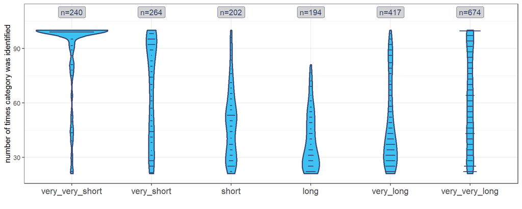

Laura Biggins

2020-01-16